# Practice Project - STAR Data

Ishita Dutta

2/8/2022

# Abstract

We will be taking the Project STAR data and analyzing how class sizes affected first graders in terms of mathematics scores. In this, I have chosen to list mean and use boxplots to show summary statistics and how much of a pull outliers can potentially have on any models we create. Here, we are using a standard ANOVA table and Tukey’s test in order to see which class size is most significantly optimal, since the ANOVA table points out that there is a significance with class size. The Tukey’s test shows us that the smallest class size helped students the most with their test scores. This can be inferred as a result of students having more time to ask questions to the teacher from the smaller class size, as well as a more personalized learning curve, since the teacher has less people they have to focus on.

# Introduction

We are looking at the data from project STAR, an experiment conducted in Tennessee seeing how student testing scores are impacted by class size and teacher aid across multiple grades.

In this project, we will be focusing only on students in grade 1 and looking at specifically their math test scores for. Here, we will try to answer whether class size really mattered in terms of scores for these first graders. In the case that a different class size really produced significantly differing results, we then want to look at which class size produces the most optimal conditions. In simpler terms, we want to see which class size ends up producing the highest math results amongst the first graders.

# Background

This is a part of the original report done between 1985 and 1989 [(source)](https://www.rdocumentation.org/packages/AER/versions/1.2-9/topics/STAR) in which multiple grades over a range of subjects were involved, and the conclusions even included which connotations of students benefited most from which class size. This data was collected from 79 schools over 4 years and not only collected average score, but the demographic and socioeconomic factors of every teacher and student per school.The sample size was kept large to avoid confounding in terms of the demographics, as well as avoiding the problem in size reduction by student movement.

Overall, the results showed higher scores in smaller classes across average scores of all subjects. Influenced by the original project, the State of Tennessee decided to launch Project Challenge, in which it funded counties for reduced class sizes across grades K-3.

Though our analysis for this project is not this deep, we are looking forward to telling which class size is best for children trying to score optimally in mathematics in the first grade, provided that there really is a difference in score with the class size to begin with.

# Descriptive analysis

```
## Failed to find G1READ_A
## Failed to find G1MATH_A
## Failed to find G2READ_A
## Failed to find G2MATH_A
## Failed to find G3READ_A
## Failed to find G3MATH_A
```

```
## Formatted Data
```

```
## # A tibble: 6 × 4
##   g1tmathss g1schid              g1classtype  g1tchid
##       <dbl>   <dbl>                <dbl+lbl>    <dbl>
## 1       578  170295 3 [REGULAR + AIDE CLASS] 17029507
## 2       507  257899 2 [REGULAR CLASS]        25789906
## 3       526  244697 2 [REGULAR CLASS]        24469708
## 4       505  244697 3 [REGULAR + AIDE CLASS] 24469709
## 5       463  244697 3 [REGULAR + AIDE CLASS] 24469709
## 6       542  205492 3 [REGULAR + AIDE CLASS] 20549205
```

```
## Summary Data
```

```
## # A tibble: 6 × 4
##   mean_score class_type           school_id teacher_id
##        <dbl> <fct>                <fct>     <fct>
## 1       487. REGULAR + AIDE CLASS 112038    11203804
## 2       500. SMALL CLASS          112038    11203805
## 3       496. REGULAR CLASS        112038    11203806
## 4       524. REGULAR CLASS        123056    12305604
## 5       533. REGULAR + AIDE CLASS 123056    12305605
## 6       534. SMALL CLASS          123056    12305606
```

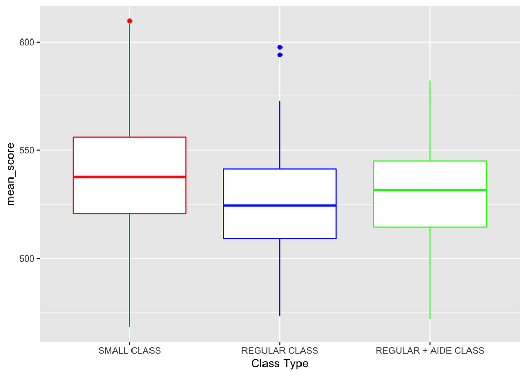

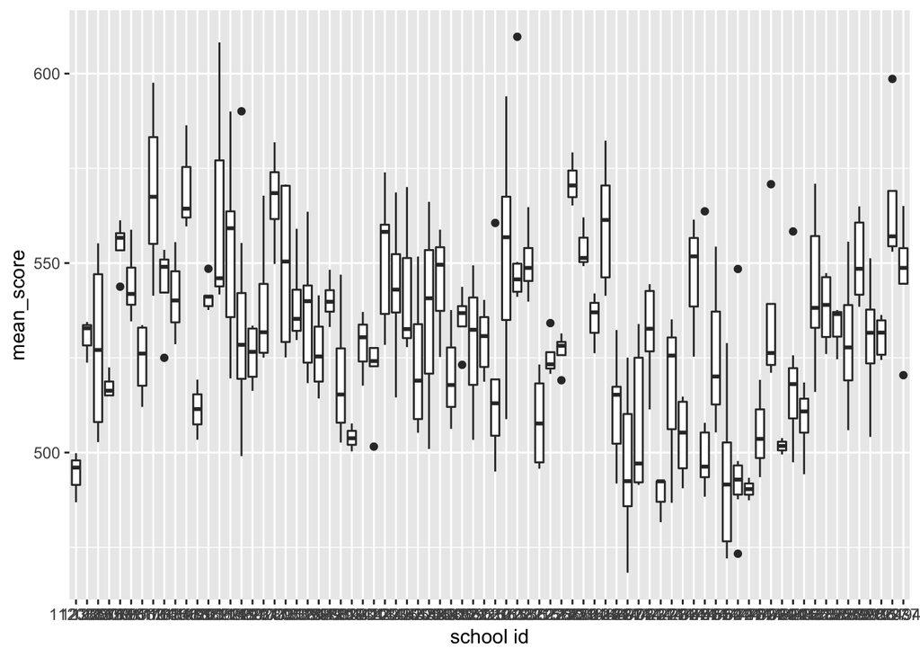

```
##    Min. 1st Qu.  Median    Mean 3rd Qu.    Max.
##   488.8   519.2   531.1   531.5   544.4   571.3
```

I chose the boxplot and mean as they are generally good measures of center. The mean gives an average value over each group as an observation average, while the boxplots help show spread as well as outliers. The significance of the boxplot is that it tells us how much our mean can be possibly skewed, and therefore affect any future models we put onto the data.

# Inferential analysis

```
##              Df Sum Sq Mean Sq F value   Pr(>F)
## school_id    75 136424    1819   6.573  < 2e-16 ***
## class_type    2  12026    6013  21.730 1.87e-09 ***
## Residuals   261  72225     277
## ---
## Signif. codes:  0 '***' 0.001 '**' 0.01 '*' 0.05 '.' 0.1 ' ' 1
```

```
##   Tukey multiple comparisons of means
##     95% family-wise confidence level
##
## Fit: aov(formula = mean_score ~ school_id + class_type, data = data2)
##
## $class_type
##                                          diff        lwr       upr     p adj
## REGULAR CLASS-SMALL CLASS          -12.954892 -18.031236 -7.878549 0.0000000
## REGULAR + AIDE CLASS-SMALL CLASS   -11.068529 -16.338703 -5.798355 0.0000040
## REGULAR + AIDE CLASS-REGULAR CLASS   1.886363  -3.475085  7.247811 0.6851551
```

The two models above show high significance in the class size. This is because the ANOVA model shows p-values much more significant than if we were to run a alpha = 0.05 significance test.

The Tukey’s test shows us the idea of which class size is most optimal for math in the first grade. Going on a case-by-case analysis, the most optimal class is the small class size when compared to the other class sizes. This is highlighted because when the small class size is involved, 0 is not in the interval and the p adj value is much more significant than the alpha = 0.05 value generally run in a Tukey’s test. The only one not significant is the regular/regular with aide comparison, which also has 0 in the interval. This can only mean that it is the small class size that is causing such a drastic change in the results.

# Sensitivity analysis

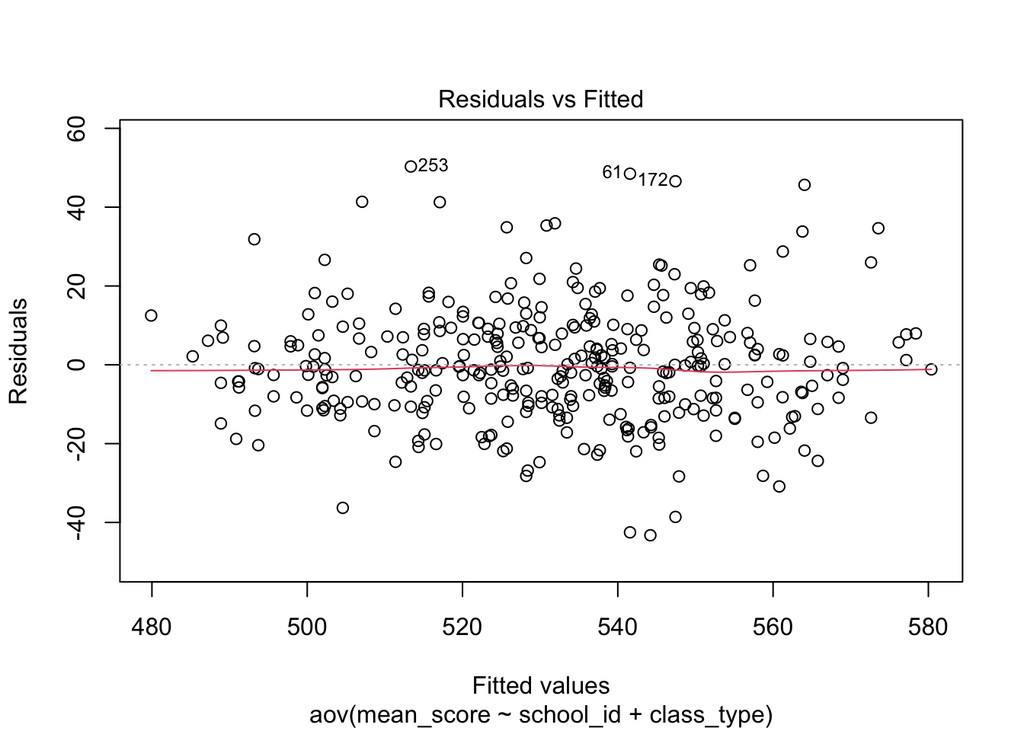

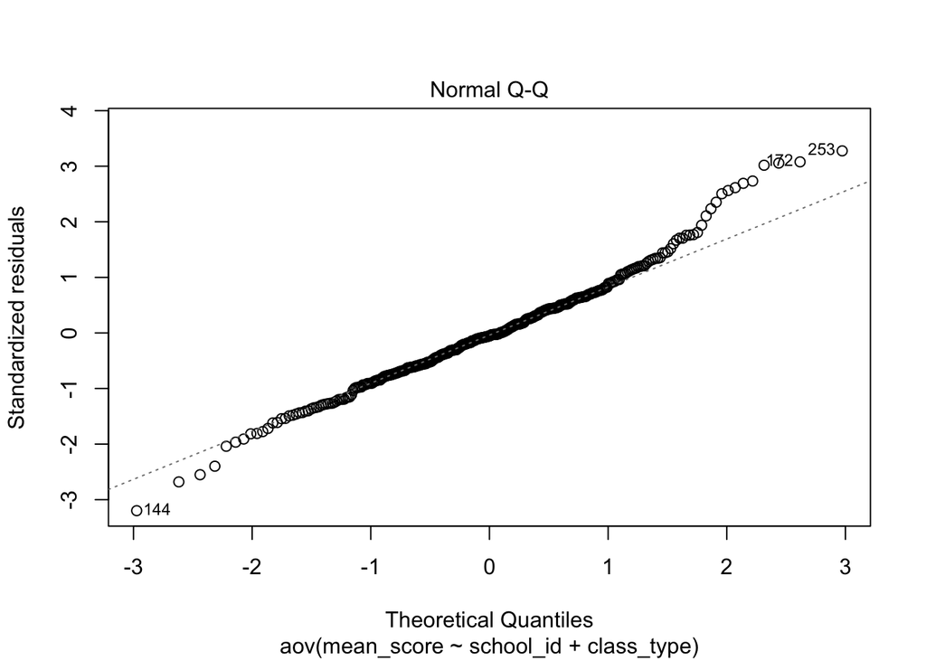

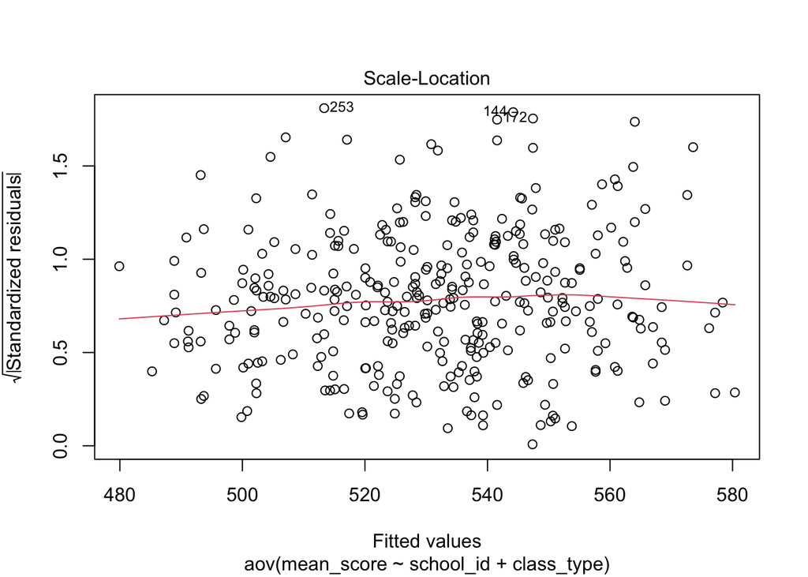

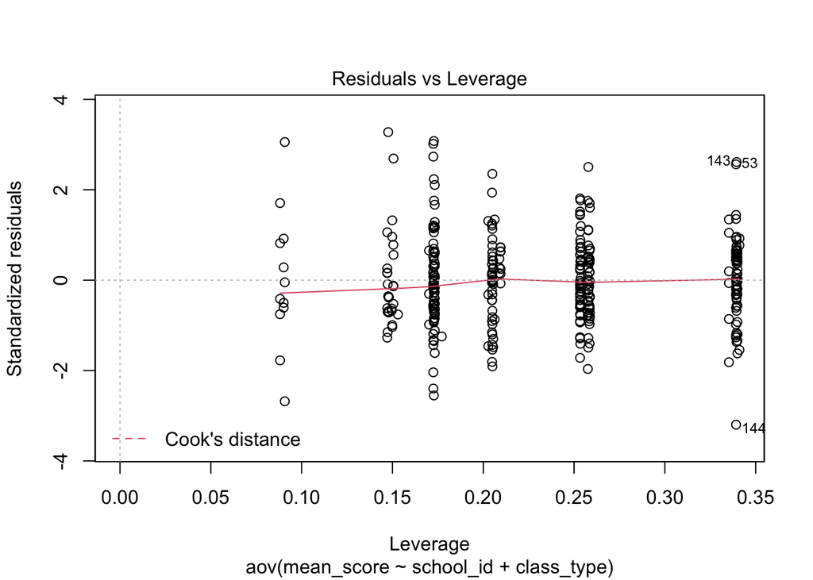

# Discussion

As mentioned in the background of the project, the State of Tennessee launched Project Challenge from the results of the original study, which was to reduce class sizes in the grades K - 3 in the 16 poorest counties of the state. From our analysis, we have also found the same, in which the small class sizes benefit the grade 1 math test scores the most. In the context of classrooms, we can infer this is because every student has more time to ask questions in a smaller class size, and therefore is set up for better comprehension of the given topics. Further policy making can be seen in the future, especially if the study is repeated in a place like California, where populations are higher.

# Acknowledgement

Did not discuss project with other people outside class.

# Reference

Boyd-Zaharias, Jayne. “Project STAR - The Story of the Tennessee Class-Size Study.” American Federation of Teachers, https://www.aft.org/sites/default/files/periodicals/STARSummer99.pdf.

# Code Appendix

```r
library(knitr)
knitr::opts_chunk$set(echo = FALSE, tidy = FALSE)
#Getting data properly to begin with
library(haven)
STAR = read_sav("STAR_Students.sav")
avai_id = which(!is.na(STAR$g1tmathss))
data = STAR[avai_id,c("g1tmathss", "g1schid", "g1classtype", "g1tchid")]

#Data we will be working with:
cat("Formatted Data")
head(data)



#Descriptive Analysis:
library(tidyverse)
data2 = data %>%
          group_by(g1tchid) %>%
          summarise(mean_score=mean(g1tmathss), # You can use other summary statistics
                    g1schid=unique(g1schid),
                    g1classtype=unique(g1classtype)) %>%
          mutate(class_type = as_factor(g1classtype, levels="labels"),
                 school_id = as_factor(g1schid),
                 teacher_id = as_factor(g1tchid),
                 .keep = "unused")

#Summary Data
cat("Summary Data")
head(data2)
ggplot(data=data2, mapping=aes(x=class_type, y=mean_score)) +
  geom_boxplot(color = c("red", "blue", "green")) +
  xlab("Class Type")
ggplot(data=data2, mapping=aes(x=school_id, y=mean_score)) +
  geom_boxplot() +
  xlab("school id")
tmp = data2 %>%
        group_by(school_id) %>%
        summarise(sch_mean=mean(mean_score))
summary(tmp$sch_mean)
#Anova model
model1 = aov(mean_score~school_id+class_type, data=data2)
summary(model1)
#Tukey test
TukeyHSD(model1, "class_type")
plot(model1)

sessionInfo()
```